# Corporate Finance Assignment 5

Nitish Ramkumar

# Assignment 3

### Dataset building

To compare, lets build a PERM,YYYYMMDD,Ret table which has PERMNO starting with only 100. Sample of the merged dataset is:

```
##   PERMNO     date AnnualReturn.x MarketCap.x AnnualReturn.y MarketCap.y
## 1  10001 20131231    -0.09069281    91759.22    -0.14550160    83929557
## 2  10001 20141231     0.44274846   113857.61     0.32142265   115577765
## 3  10002 20131231     0.03597128          NA             NA   332811410
## 4  10025 20131231    -0.10805332   390254.77    -0.11434892  1598190884
## 5  10025 20141231     0.10070035   215370.98     0.09594666  1922848867
## 6  10026 20131231     0.40029528  1469231.36     0.32696412    30318240
```

x is my data, and y is Forrest’s data.

### Comparison Analysis

**Returns**

If we see the plot of returns between the annualized returns of me and Forrest, we notice that it is not along the 45 degree line (green line).

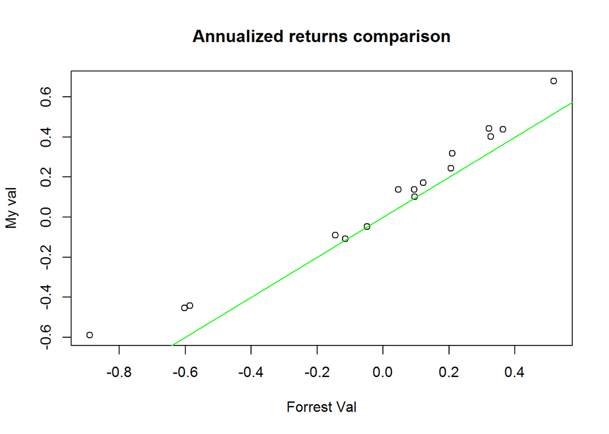

This difference in values is because Forrest has correctly maintained the log of returns in the Annual return column, whereas I have maintained the actual returns.

**MarketCap**

I didn’t multiply the value by 1000, which Forrest has correctly done. If we plot the market cap between the two datasets,

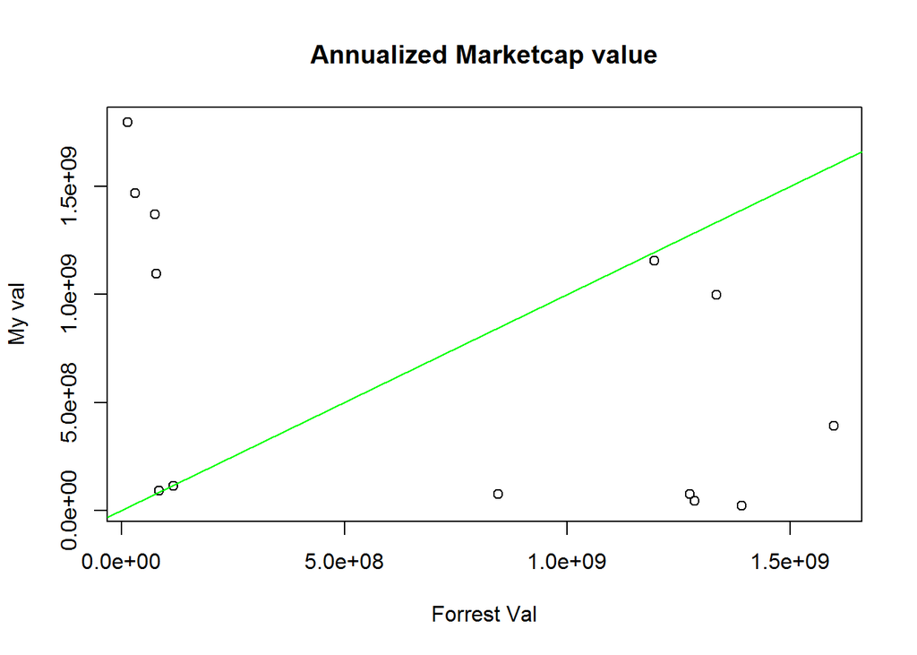

One reason I can point out for this is that I have taken annual market cap as average of all monthly market caps. Forrest has maintained the year end value as marketcap.

### Reconciliation

1. Both of us should use log returns
2. Use same standard for market cap value (either average or end of year value)